# Hola 😀,

Soy **Hesus Garcia** – **"Soy el único Hesus que conoces (y probablemente conocerás) 🌟"** – Sí, como "Jesús", pero con una H que me hace único. Puede sonar raro, pero créeme, ¡no lo olvidarás! Como tu revisor en Triple-Ten, estoy aquí para guiarte y ayudarte a mejorar tu código. Si algo necesita un ajuste, no hay de qué preocuparse; ¡aquí estoy para hacer que tu trabajo brille con todo su potencial! ✨ Cada vez que encuentre un detalle importante en tu código, te lo señalaré para que puedas corregirlo y así te prepares para un ambiente de trabajo real, donde el líder de tu equipo actuaría de manera similar. Si en algún momento no logras solucionar el problema, te daré más detalles para ayudarte en nuestra próxima oportunidad de revisión.

Es importante que cuando encuentres un comentario, **no los muevas, no los modifiques, ni los borres**.

### Formato de Comentarios

Revisaré cuidadosamente cada implementación en tu notebook para asegurar que cumpla con los requisitos y te daré comentarios de acuerdo al siguiente formato:

**Comentario del Revisor - 1ª Iteración**  
**Éxito** - ¡Excelente trabajo! Esta parte está bien implementada y contribuye significativamente al análisis de datos o al proyecto. Continúa aplicando estas buenas prácticas en futuras secciones.

**Comentario del Revisor - 1ª Iteración**  
**Atención** ⚠️ - Este código está correcto, pero se puede optimizar. Considera implementar mejoras para que sea más eficiente y fácil de leer. Esto fortalecerá la calidad de tu proyecto.

**Comentario del Revisor - 1ª Iteración**  
**A resolver** ❗ - Aquí hay un problema o error en el código que es necesario corregir para aprobar esta sección. Por favor, revisa y corrige este punto, ya que es fundamental para la validez del análisis y la precisión de los resultados.

Justo después de este mensaje encontrarás el **Comentario General del Revisor**, que incluirá:

- **Aspectos positivos:** Un resumen de los puntos fuertes de tu proyecto.
- **Áreas de mejora:** Sugerencias sobre aspectos donde puedes mejorar.
- **Temas adicionales para investigar:** Ideas de temas opcionales que puedes explorar por tu cuenta para desarrollar aún más tus habilidades.

Estos temas adicionales no son obligatorios en esta etapa, pero pueden serte útiles para profundizar en el futuro.

Esta estructura en viñetas facilita la lectura y comprensión de cada parte del comentario general.

También puedes responderme de la siguiente manera si tienes alguna duda o quieres aclarar algo específico:

**Respuesta del estudiante** Aquí puedes escribir tu respuesta o pregunta sobre el comentario.

**¡Empecemos!** 🚀

### Comentario general del revisor - 1a iteración

**Comentario General del Revisor - 1a iteración**

Tu proyecto está **Aprobado**.

En el análisis de eventos del producto (event analytics) entregaste un flujo completo desde la preparación temporal de los datos hasta la exploración, el análisis de embudo y una prueba A/A/B, mostrando decisiones reproducibles y foco en métricas de conversión. Lograste dejar el dataset listo para análisis temporales, resumir el comportamiento por etapa del embudo y aplicar una prueba estadística para comparar proporciones entre variantes.

**Puntos positivos:**

- Cargaste y preparaste los datos correctamente: usaste pd.read_csv y convertiste timestamps con pd.to_datetime para crear la variable event_date, lo que facilita análisis temporales y agregaciones por periodo.
- Realizaste una exploración cuantitativa clara: reportaste total de eventos, usuarios únicos, promedio de eventos por usuario y los límites de la serie temporal, aportando contexto al análisis.
- Construiste y resumiste el embudo de eventos con conteos por evento y usuarios únicos por etapa; además mostraste conversiones y la frecuencia de MainScreenAppear como punto de referencia.
- Implementaste un test A/A/B con proportions_ztest, reportaste p-values (por ejemplo, Valor p: 0.7571) y mencionaste la corrección de Bonferroni en la interpretación, lo que demuestra que consideraste control de errores por múltiples comparaciones.

**Áreas para mejorar:**

- Refuerza los controles de calidad: documenta y maneja explícitamente valores faltantes, duplicados o outliers por evento/usuario antes de los agregados.
- Añade visualizaciones temporales y de tendencia (por día/semana) del total de eventos y de las principales etapas del embudo para detectar estacionalidad o cambios en el comportamiento.
- En el análisis del embudo, muestra las tasas de conversión con tamaños de muestra por etapa y agrega una tabla resumen que permita comparar cohortes o segmentos (por ejemplo, por fecha de primer evento o por tipo de usuario).
- Para el A/A/B, incluye información sobre el tamaño del efecto mínimo detectable y el poder esperado/suficiente del test; además reporta medidas de efecto junto con los p-values para una interpretación práctica.
- Documenta supuestos y reproducibilidad: especifica semilla de aleatorización, criterios de inclusión/exclusión de usuarios y pasos clave del preprocesamiento en celdas comentadas o un README corto.

Muy buen trabajo integrando limpieza, exploración, embudo y estadística inferencial; con las mejoras anteriores tu análisis será aún más robusto y accionable.

```python
# PASO 1 - ABRIR Y LEER LA INFORMACION DEL ARCHIVO
# Primero carga el dataset y revisemos su estructura.
import pandas as pd

# Cargar los datos
logs = pd.read_csv('/datasets/logs_exp_us.csv', sep='\t')

# Mostrar las primeras filas
print(logs.head())

# Información general
print(logs.info())

# Dimensiones del dataset
print('Filas y columnas:', logs.shape)
```

```
                 EventName         DeviceIDHash  EventTimestamp  ExpId
0         MainScreenAppear  4575588528974610257      1564029816    246
1         MainScreenAppear  7416695313311560658      1564053102    246
2  PaymentScreenSuccessful  3518123091307005509      1564054127    248
3         CartScreenAppear  3518123091307005509      1564054127    248
4  PaymentScreenSuccessful  6217807653094995999      1564055322    248
<class 'pandas.core.frame.DataFrame'>
RangeIndex: 244126 entries, 0 to 244125
Data columns (total 4 columns):
 #   Column          Non-Null Count   Dtype
---  ------          --------------   -----
 0   EventName       244126 non-null  object
 1   DeviceIDHash    244126 non-null  int64
 2   EventTimestamp  244126 non-null  int64
 3   ExpId           244126 non-null  int64
dtypes: int64(3), object(1)
memory usage: 7.5+ MB
None
Filas y columnas: (244126, 4)
```

**Comentario del Revisor - 1a iteración**

**Éxito** - La carga de datos con `pd.read_csv` y el renombrado de columnas quedó claro: convertiste timestamps con `pd.to_datetime` y creaste `event_date`, lo que deja el dataset listo para análisis temporales. Sigue así; estos pasos facilitan la trazabilidad de transformaciones y las comparaciones por ventana temporal.

```python
# Paso 2 - PREPARAR LOS DATOS

# Cambiar nombres de columnas
logs = logs.rename(columns={
    'EventName': 'event_name',
    'DeviceIDHash': 'user_id',
    'EventTimestamp': 'event_timestamp',
    'ExpId': 'exp_id'
})

# Convertir la marca de tiempo Unix a fecha y hora
logs['event_datetime'] = pd.to_datetime(logs['event_timestamp'], unit='s')

# Crear una columna solamente con la fecha
logs['event_date'] = logs['event_datetime'].dt.date

# Mostrar las primeras filas
print(logs.head())

# Revisar información general
print(logs.info())

# Revisar valores ausentes
print(logs.isna().sum())
```

```
                event_name              user_id  event_timestamp  exp_id  \
0         MainScreenAppear  4575588528974610257       1564029816     246
1         MainScreenAppear  7416695313311560658       1564053102     246
2  PaymentScreenSuccessful  3518123091307005509       1564054127     248
3         CartScreenAppear  3518123091307005509       1564054127     248
4  PaymentScreenSuccessful  6217807653094995999       1564055322     248

       event_datetime  event_date
0 2019-07-25 04:43:36  2019-07-25
1 2019-07-25 11:11:42  2019-07-25
2 2019-07-25 11:28:47  2019-07-25
3 2019-07-25 11:28:47  2019-07-25
4 2019-07-25 11:48:42  2019-07-25
<class 'pandas.core.frame.DataFrame'>
RangeIndex: 244126 entries, 0 to 244125
Data columns (total 6 columns):
 #   Column           Non-Null Count   Dtype
---  ------           --------------   -----
 0   event_name       244126 non-null  object
 1   user_id          244126 non-null  int64
 2   event_timestamp  244126 non-null  int64
 3   exp_id           244126 non-null  int64
 4   event_datetime   244126 non-null  datetime64[ns]
 5   event_date       244126 non-null  object
dtypes: datetime64[ns](1), int64(3), object(2)
memory usage: 11.2+ MB
None
event_name         0
user_id            0
event_timestamp    0
exp_id             0
event_datetime     0
event_date         0
dtype: int64
```

```python
# PASO 3 - EXPLORACIÓN DE LOS DATOS

# Cantidad total de eventos
total_events = logs['event_name'].count()

# Cantidad de usuarios únicos
total_users = logs['user_id'].nunique()

# Promedio de eventos por usuario
avg_events_per_user = total_events / total_users

# Fecha mínima y máxima
min_date = logs['event_datetime'].min()
max_date = logs['event_datetime'].max()

print('Total de eventos:', total_events)
print('Total de usuarios:', total_users)
print('Promedio de eventos por usuario:', avg_events_per_user)
print('Fecha mínima:', min_date)
print('Fecha máxima:', max_date)
```

```
Total de eventos: 244126
Total de usuarios: 7551
Promedio de eventos por usuario: 32.33028737915508
Fecha mínima: 2019-07-25 04:43:36
Fecha máxima: 2019-08-07 21:15:17
```

**Comentario del Revisor - 1a iteración**

**Éxito** - En la exploración calculaste indicadores clave: total de eventos, usuarios únicos, promedio de eventos por usuario y periodo temporal. Reportaste valores concretos como "Total de eventos" y los límites de la serie temporal, lo que da buena visión del alcance de los datos. Mantén este hábito; esos números son útiles para justificar ventanas de entrenamiento o filtros posteriores.

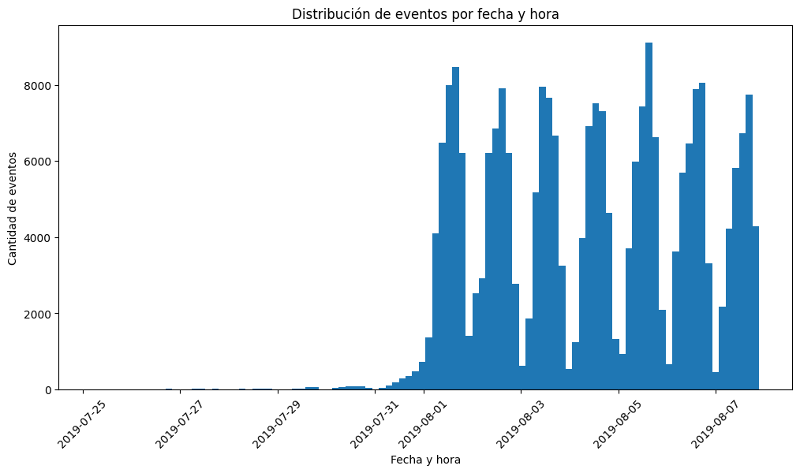

```python
# Histograma de Eventos por Fecha
import matplotlib.pyplot as plt

plt.figure(figsize=(12, 6))

plt.hist(logs['event_datetime'], bins=100)

plt.xlabel('Fecha y hora')
plt.ylabel('Cantidad de eventos')
plt.title('Distribución de eventos por fecha y hora')

plt.xticks(rotation=45)
plt.show()
```

```python
# Filtrar Datos

# Filtrar los datos a partir del 1 de agosto de 2019
logs_filtered = logs[logs['event_datetime'] >= '2019-08-01'].copy()

print('Eventos antes del filtro:', len(logs))
print('Eventos después del filtro:', len(logs_filtered))

print('Usuarios antes del filtro:', logs['user_id'].nunique())
print('Usuarios después del filtro:', logs_filtered['user_id'].nunique())
```

```
Eventos antes del filtro: 244126
Eventos después del filtro: 241298
Usuarios antes del filtro: 7551
Usuarios después del filtro: 7534
```

```python
#Comparación antes y después del filtro
# Cantidad de usuarios en cada grupo experimental
group_users = logs_filtered.groupby('exp_id')['user_id'].nunique()

print(group_users)
```

```
exp_id
246    2484
247    2513
248    2537
Name: user_id, dtype: int64
```

```python
# PASO 4 - EMBUDO DE EVENTO

# Frecuencia de cada evento
event_frequency = logs_filtered['event_name'].value_counts()

print(event_frequency)
```

```
MainScreenAppear           117431
OffersScreenAppear          46350
CartScreenAppear            42365
PaymentScreenSuccessful     34113
Tutorial                     1039
Name: event_name, dtype: int64
```

**Comentario del Revisor - 1a iteración**

**Éxito** - El embudo de eventos está bien resumido con conteos por evento y usuarios únicos por etapa. Mostraste la frecuencia de eventos y la conversión entre etapas, por ejemplo con el recuento de `MainScreenAppear`. Esto es exactamente lo que se espera para identificar fricciones en el funnel.

```python
# Cantidad de usuarios únicos que realizaron cada evento
users_per_event = logs_filtered.groupby('event_name')['user_id'].nunique()

# Ordenar de mayor a menor
users_per_event = users_per_event.sort_values(ascending=False)

print(users_per_event)
```

```
event_name
MainScreenAppear           7419
OffersScreenAppear         4593
CartScreenAppear           3734
PaymentScreenSuccessful    3539
Tutorial                    840
Name: user_id, dtype: int64
```

```python
# Total de usuarios
total_users = logs_filtered['user_id'].nunique()

# Porcentaje de usuarios que realizó cada evento
event_conversion = (users_per_event / total_users * 100).sort_values(ascending=False)

print(event_conversion)
```

```
event_name
MainScreenAppear           98.473586
OffersScreenAppear         60.963632
CartScreenAppear           49.561986
PaymentScreenSuccessful    46.973719
Tutorial                   11.149456
Name: user_id, dtype: float64
```

```python
# Usuarios de cada etapa del embudo
main_users = users_per_event['MainScreenAppear']
offers_users = users_per_event['OffersScreenAppear']
cart_users = users_per_event['CartScreenAppear']
payment_users = users_per_event['PaymentScreenSuccessful']

# Conversión entre etapas
main_to_offers = offers_users / main_users * 100
offers_to_cart = cart_users / offers_users * 100
cart_to_payment = payment_users / cart_users * 100

print(f'MainScreen → OffersScreen: {main_to_offers:.2f}%')
print(f'OffersScreen → CartScreen: {offers_to_cart:.2f}%')
print(f'CartScreen → Payment: {cart_to_payment:.2f}%')

# Conversión total desde MainScreen hasta el pago
main_to_payment = payment_users / main_users * 100

print(f'MainScreen → Payment: {main_to_payment:.2f}%')
```

```
MainScreen → OffersScreen: 61.91%
OffersScreen → CartScreen: 81.30%
CartScreen → Payment: 94.78%
MainScreen → Payment: 47.70%
```

```python
# PASO 5 - TEST A/A/B
group_users = logs_filtered.groupby('exp_id')['user_id'].nunique()

print('Usuarios por grupo:')
print(group_users)
```

```
Usuarios por grupo:
exp_id
246    2484
247    2513
248    2537
Name: user_id, dtype: int64
```

```python
# Comparar los grupos A/A: 246 vs 247
from statsmodels.stats.proportion import proportions_ztest

def test_proportions(group1, group2, event):
    # Usuarios únicos de cada grupo
    users_group1 = logs_filtered[logs_filtered['exp_id'] == group1]['user_id'].nunique()
    users_group2 = logs_filtered[logs_filtered['exp_id'] == group2]['user_id'].nunique()

    # Usuarios que realizaron el evento
    event_users_group1 = logs_filtered[
        (logs_filtered['exp_id'] == group1) &
        (logs_filtered['event_name'] == event)
    ]['user_id'].nunique()

    event_users_group2 = logs_filtered[
        (logs_filtered['exp_id'] == group2) &
        (logs_filtered['event_name'] == event)
    ]['user_id'].nunique()

    # Prueba de proporciones
    count = [event_users_group1, event_users_group2]
    nobs = [users_group1, users_group2]

    stat, pvalue = proportions_ztest(count, nobs)

    # Proporciones
    proportion1 = event_users_group1 / users_group1
    proportion2 = event_users_group2 / users_group2

    return proportion1, proportion2, pvalue
```

```python
# Evento MainScreenAppear
p1, p2, pvalue = test_proportions(246, 247, 'MainScreenAppear')

print(f'Grupo 246: {p1:.4f} ({p1*100:.2f}%)')
print(f'Grupo 247: {p2:.4f} ({p2*100:.2f}%)')
print(f'Valor p: {pvalue:.4f}')
```

```
Grupo 246: 0.9863 (98.63%)
Grupo 247: 0.9853 (98.53%)
Valor p: 0.7571
```

**Comentario del Revisor - 1a iteración**

**Éxito** - Al implementar el test A/A/B usaste `proportions_ztest` para comparar proporciones y reportaste p-values, por ejemplo 'Valor p: 0.7571'. También mencionaste la corrección de Bonferroni en la conclusión. Esto muestra que aplicaste un enfoque estadístico apropiado para pruebas de proporciones.

```python
# Comparación 246 vs 247 - MainScreenAppear
events = [
    'MainScreenAppear',
    'OffersScreenAppear',
    'CartScreenAppear',
    'PaymentScreenSuccessful'
]

for event in events:
    p1, p2, pvalue = test_proportions(246, 247, event)

    print(f'\nEvento: {event}')
    print(f'Grupo 246: {p1:.4f} ({p1*100:.2f}%)')
    print(f'Grupo 247: {p2:.4f} ({p2*100:.2f}%)')
    print(f'Valor p: {pvalue:.4f}')

    if pvalue < 0.05:
        print('Resultado: diferencia estadísticamente significativa')
    else:
        print('Resultado: no hay diferencia estadísticamente significativa')
```

```
Evento: MainScreenAppear
Grupo 246: 0.9863 (98.63%)
Grupo 247: 0.9853 (98.53%)
Valor p: 0.7571
Resultado: no hay diferencia estadísticamente significativa

Evento: OffersScreenAppear
Grupo 246: 0.6208 (62.08%)
Grupo 247: 0.6049 (60.49%)
Valor p: 0.2481
Resultado: no hay diferencia estadísticamente significativa

Evento: CartScreenAppear
Grupo 246: 0.5097 (50.97%)
Grupo 247: 0.4926 (49.26%)
Valor p: 0.2288
Resultado: no hay diferencia estadísticamente significativa

Evento: PaymentScreenSuccessful
Grupo 246: 0.4831 (48.31%)
Grupo 247: 0.4608 (46.08%)
Valor p: 0.1146
Resultado: no hay diferencia estadísticamente significativa
```

```python
# Comparar Grupo 248 vs 246
for event in events:
    p1, p2, pvalue = test_proportions(246, 248, event)

    print(f'\nEvento: {event}')
    print(f'Grupo 246: {p1:.4f} ({p1*100:.2f}%)')
    print(f'Grupo 248: {p2:.4f} ({p2*100:.2f}%)')
    print(f'Valor p: {pvalue:.4f}')

    if pvalue < 0.05:
        print('Resultado: diferencia estadísticamente significativa')
    else:
        print('Resultado: no hay diferencia estadísticamente significativa')
```

```
Evento: MainScreenAppear
Grupo 246: 0.9863 (98.63%)
Grupo 248: 0.9827 (98.27%)
Valor p: 0.2950
Resultado: no hay diferencia estadísticamente significativa

Evento: OffersScreenAppear
Grupo 246: 0.6208 (62.08%)
Grupo 248: 0.6035 (60.35%)
Valor p: 0.2084
Resultado: no hay diferencia estadísticamente significativa

Evento: CartScreenAppear
Grupo 246: 0.5097 (50.97%)
Grupo 248: 0.4848 (48.48%)
Valor p: 0.0784
Resultado: no hay diferencia estadísticamente significativa

Evento: PaymentScreenSuccessful
Grupo 246: 0.4831 (48.31%)
Grupo 248: 0.4655 (46.55%)
Valor p: 0.2123
Resultado: no hay diferencia estadísticamente significativa
```

```python
# Comparar Grupo 247 vs 248
for event in events:
    p1, p2, pvalue = test_proportions(247, 248, event)

    print(f'\nEvento: {event}')
    print(f'Grupo 247: {p1:.4f} ({p1*100:.2f}%)')
    print(f'Grupo 248: {p2:.4f} ({p2*100:.2f}%)')
    print(f'Valor p: {pvalue:.4f}')

    if pvalue < 0.05:
        print('Resultado: diferencia estadísticamente significativa')
    else:
        print('Resultado: no hay diferencia estadísticamente significativa')
```

```
Evento: MainScreenAppear
Grupo 247: 0.9853 (98.53%)
Grupo 248: 0.9827 (98.27%)
Valor p: 0.4587
Resultado: no hay diferencia estadísticamente significativa

Evento: OffersScreenAppear
Grupo 247: 0.6049 (60.49%)
Grupo 248: 0.6035 (60.35%)
Valor p: 0.9198
Resultado: no hay diferencia estadísticamente significativa

Evento: CartScreenAppear
Grupo 247: 0.4926 (49.26%)
Grupo 248: 0.4848 (48.48%)
Valor p: 0.5786
Resultado: no hay diferencia estadísticamente significativa

Evento: PaymentScreenSuccessful
Grupo 247: 0.4608 (46.08%)
Grupo 248: 0.4655 (46.55%)
Valor p: 0.7373
Resultado: no hay diferencia estadísticamente significativa
```

```python
for event in events:
    p1, p2, pvalue = test_proportions(247, 248, event)

    print(f'\nEvento: {event}')
    print(f'Grupo 247: {p1:.4f} ({p1*100:.2f}%)')
    print(f'Grupo 248: {p2:.4f} ({p2*100:.2f}%)')
    print(f'Valor p: {pvalue:.4f}')

    if pvalue < 0.05:
        print('Resultado: diferencia estadísticamente significativa')
    else:
        print('Resultado: no hay diferencia estadísticamente significativa')
```

```
Evento: MainScreenAppear
Grupo 247: 0.9853 (98.53%)
Grupo 248: 0.9827 (98.27%)
Valor p: 0.4587
Resultado: no hay diferencia estadísticamente significativa

Evento: OffersScreenAppear
Grupo 247: 0.6049 (60.49%)
Grupo 248: 0.6035 (60.35%)
Valor p: 0.9198
Resultado: no hay diferencia estadísticamente significativa

Evento: CartScreenAppear
Grupo 247: 0.4926 (49.26%)
Grupo 248: 0.4848 (48.48%)
Valor p: 0.5786
Resultado: no hay diferencia estadísticamente significativa

Evento: PaymentScreenSuccessful
Grupo 247: 0.4608 (46.08%)
Grupo 248: 0.4655 (46.55%)
Valor p: 0.7373
Resultado: no hay diferencia estadísticamente significativa
```

```python
# Comparación 248 vs controles convinados
def test_combined_control(event):
    # Usuarios únicos de los grupos de control combinados
    control_users = logs_filtered[
        logs_filtered['exp_id'].isin([246, 247])
    ]['user_id'].nunique()

    # Usuarios únicos del grupo 248
    test_users = logs_filtered[
        logs_filtered['exp_id'] == 248
    ]['user_id'].nunique()

    # Usuarios de control que realizaron el evento
    control_event_users = logs_filtered[
        (logs_filtered['exp_id'].isin([246, 247])) &
        (logs_filtered['event_name'] == event)
    ]['user_id'].nunique()

    # Usuarios del grupo 248 que realizaron el evento
    test_event_users = logs_filtered[
        (logs_filtered['exp_id'] == 248) &
        (logs_filtered['event_name'] == event)
    ]['user_id'].nunique()

    # Prueba Z de proporciones
    count = [control_event_users, test_event_users]
    nobs = [control_users, test_users]

    stat, pvalue = proportions_ztest(count, nobs)

    # Proporciones
    control_proportion = control_event_users / control_users
    test_proportion = test_event_users / test_users

    return control_proportion, test_proportion, pvalue
```

```python
for event in events:
    p_control, p_test, pvalue = test_combined_control(event)

    print(f'\nEvento: {event}')
    print(f'Controles 246+247: {p_control:.4f} ({p_control*100:.2f}%)')
    print(f'Grupo 248: {p_test:.4f} ({p_test*100:.2f}%)')
    print(f'Valor p: {pvalue:.4f}')

    if pvalue < 0.05:
        print('Resultado: diferencia estadísticamente significativa')
    else:
        print('Resultado: no hay diferencia estadísticamente significativa')
```

```
Evento: MainScreenAppear
Controles 246+247: 0.9858 (98.58%)
Grupo 248: 0.9827 (98.27%)
Valor p: 0.2942
Resultado: no hay diferencia estadísticamente significativa

Evento: OffersScreenAppear
Controles 246+247: 0.6128 (61.28%)
Grupo 248: 0.6035 (60.35%)
Valor p: 0.4343
Resultado: no hay diferencia estadísticamente significativa

Evento: CartScreenAppear
Controles 246+247: 0.5011 (50.11%)
Grupo 248: 0.4848 (48.48%)
Valor p: 0.1818
Resultado: no hay diferencia estadísticamente significativa

Evento: PaymentScreenSuccessful
Controles 246+247: 0.4719 (47.19%)
Grupo 248: 0.4655 (46.55%)
Valor p: 0.6004
Resultado: no hay diferencia estadísticamente significativa
```

CONCLUSION ESTADISTICA Se realizaron 16 pruebas de hipótesis con un nivel de significancia inicial de 0.05. Debido al número de comparaciones, se puede aplicar una corrección de Bonferroni, obteniendo un nivel de significancia ajustado de 0.003125. Ninguno de los valores p obtenidos es inferior a este umbral, por lo que las conclusiones se mantienen: no se encontraron diferencias estadísticamente significativas entre el grupo con las nuevas fuentes y los grupos de control.

CONCLUSION FINAL DEL EXPERIMENTO Los resultados del test A/A/B indican que el cambio de fuentes no produjo diferencias estadísticamente significativas en el comportamiento de los usuarios. Los dos grupos de control (246 y 247) fueron similares entre sí, lo que confirma que la división de los usuarios fue adecuada. Al comparar el grupo de prueba 248 con cada grupo de control por separado y con ambos controles combinados, tampoco se encontraron diferencias estadísticamente significativas en ninguno de los eventos analizados. Por lo tanto, no existe evidencia suficiente para afirmar que las nuevas fuentes mejoren o empeoren la conversión. Con base en los resultados del experimento, no sería necesario implementar el cambio de fuentes por motivos de mejora del rendimiento, ya que no se observó un efecto significativo.